# Pentathlon II

## Setup

Create an Rmarkdown document in which you calculate the CLV for each of the plans over an 8 week periods. The relevant data is in `data/pentathlon-II.xls` Also, use the average subscription churn and revenue numbers provided in `data/pentathlon-II-avg.csv` to simulate the effect of the different email frequencies over a 104 week period and generate a line plot to compare the five CLV curves. Are your results consistent with your answer to question 3 in the pentathlon-II.pdf file on Dropbox? Why (or why not)?

## Analysis

Load both the `data/pentathlon-II.xls` and `data/pentathlon-II-avg.csv` for use in your analysis. Note that you still have to calculate the weekly discount rate based on the annual discount rate mentioned below.

The variables in `data/pentathlon-II-avg.csv` are:

- `schurn` is the average subscription churn over the 8 weeks of the test
- `rev_sub` is the average revenue from subscribers
- `rev_unsub` is the average revenue from non-subscribers

A few assumptions to start with:

```
weeks <- 1:104
discount <- .1 ## annual discount rate
cogs <- .6
```

```r
library(readxl)
library(dplyr)
library(tidyr)
data <- read.csv('data/pentathlon-II-avg.csv')
data1 <- readxl::read_xls('data/pentathlon-II.xls',col_names = FALSE)
data1 <-na.omit(data1)
cost_of_good <- 0.6
churn<- t(data1[c(2,6,10,14,18),])
get_tibble <- function(select_data){

a<- data.frame(select_data)
email1=a$X1[2:length(a$X1)]
email1 <- as.numeric(as.character(email1))
residual_rate_email1 <- 1-email1
for (i in 2: length(residual_rate_email1)){
  residual_rate_email1[i]  = residual_rate_email1[i]*residual_rate_email1[i - 1]
}
churn1 <-c(1,residual_rate_email1)
email2=a$X2[2:length(a$X2)]
email2 <- as.numeric(as.character(email2))
residual_rate_email2 <- 1-email2
for (i in 2: length(residual_rate_email2)){
  residual_rate_email2[i]  = residual_rate_email2[i]*residual_rate_email2[i - 1]
}
churn2 <-c(1,residual_rate_email2)
email3=a$X3[2:length(a$X3)]
email3 <- as.numeric(as.character(email3))
residual_rate_email3 <- 1-email3
for (i in 2: length(residual_rate_email3)){
  residual_rate_email3[i]  = residual_rate_email3[i]*residual_rate_email3[i - 1]
}
churn3 <-c(1,residual_rate_email3)
email4=a$X4[2:length(a$X4)]
email4 <- as.numeric(as.character(email4))
residual_rate_email4 <- 1-email4
for (i in 2: length(residual_rate_email4)){
  residual_rate_email4[i]  = residual_rate_email4[i]*residual_rate_email4[i - 1]
}
churn4 <-c(1,residual_rate_email4)
email5=a$X5[2:length(a$X5)]
email5 <- as.numeric(as.character(email5))
residual_rate_email5 <- 1-email5
for (i in 2: length(residual_rate_email5)){
  residual_rate_email5[i]  = residual_rate_email5[i]*residual_rate_email5[i - 1]
}
churn5 <-c(1,residual_rate_email5)
table_get <- tibble::tibble(
  chunr1 = churn1,
  chunr2 = churn2,
  chunr3 = churn3,
  chunr4 = churn4,
  chunr5 = churn5
)
return(table_get)
}
churn_get<- get_tibble(churn)
churn_get <-head(churn_get,8)
#######################


get_tibble2 <- function(select_data){

  a<- data.frame(select_data)
  email1=a$X1[2:length(a$X1)]
  email1 <- as.numeric(as.character(email1))
  email2=a$X2[2:length(a$X2)]
  email2 <- as.numeric(as.character(email2))
  email3=a$X3[2:length(a$X3)]
  email3 <- as.numeric(as.character(email3))
  email4=a$X4[2:length(a$X4)]
  email4 <- as.numeric(as.character(email4))
  email5=a$X5[2:length(a$X5)]
  email5 <- as.numeric(as.character(email5))
  table_get2 <- tibble::tibble(
    email1 = email1,
    email2 = email2,
    email3 = email3,
    email4 = email4,
    email5 = email5,
  )
  return(table_get2)
}


subscribed_revenue <- t(data1[c(3,7,11,15,19),])
subscribed_get <- get_tibble2(subscribed_revenue)
unsubscribed_revenue <- t(data1[c(4,8,12,16,20),])
unsubscribed_get <- get_tibble2(unsubscribed_revenue)






profit <- subscribed_get*churn_get*(1-cost_of_good)+unsubscribed_get*(1-churn_get)*(1-cost_of_good)
get_clv<-function(profit,number_week){
weekly_discount_rate <- 1.1^(1/52)-1
cost_of_good <-0.6
week <- 1:number_week
emailpv <- profit / (1 + weekly_discount_rate)^(week-0.5)
CLV_auto_email <- cumsum(emailpv)
AWS_auto_email <- tibble::tibble(week, CLV_auto_email)
return(AWS_auto_email)}
clv_email1 <- get_clv(profit$email1,8)
clv_email2 <- get_clv(profit$email2,8)
clv_email3 <- get_clv(profit$email3,8)
clv_email4 <- get_clv(profit$email4,8)
clv_email5 <- get_clv(profit$email5,8)
print(clv_email1)
```

```
# A tibble: 8 x 2
   week CLV_auto_email
  <int>          <dbl>
1     1          0.116
2     2          0.239
3     3          0.358
4     4          0.484
5     5          0.597
6     6          0.699
7     7          0.803
8     8          0.911
```

```r
print(clv_email2)
```

```
# A tibble: 8 x 2
   week CLV_auto_email
  <int>          <dbl>
1     1          0.140
2     2          0.283
3     3          0.421
4     4          0.581
5     5          0.702
6     6          0.829
7     7          0.937
8     8          1.07
```

```r
print(clv_email3)
```

```
# A tibble: 8 x 2
   week CLV_auto_email
  <int>          <dbl>
1     1          0.148
2     2          0.279
3     3          0.419
4     4          0.553
5     5          0.678
6     6          0.811
7     7          0.947
8     8          1.08
```

```r
print(clv_email4)
```

```
# A tibble: 8 x 2
   week CLV_auto_email
  <int>          <dbl>
1     1          0.144
2     2          0.277
3     3          0.392
4     4          0.531
5     5          0.671
6     6          0.787
7     7          0.907
8     8          1.03
```

```r
print(clv_email5)
```

```
# A tibble: 8 x 2
   week CLV_auto_email
  <int>          <dbl>
1     1          0.144
2     2          0.272
3     3          0.385
4     4          0.523
5     5          0.650
6     6          0.775
7     7          0.889
8     8          0.996
```

Question 1,Week8 CLV from email1 to 5 is 0.911,1.066,1.076,1.027,0.995 Question 2 they should adopt 3 email per week.Because in short term,week3 have relatively low churn level compare to week4 and 5 and it’s clv is highest 1.076.

```r
## insert CLV function below
## determine what arguments the function needs to generate the required
## return value
clv <- function(rev_sub,rev_unsub,churn) {
weeks <- 1:104
discount <- .1 ## annual discount rate
cogs <- .6
week_discount<-(1+discount)^(1/52)-1
revenue_week <-tibble::tibble(weeks, revenue_sub=rev_sub,revenue_unsub=rev_unsub,churn=1-churn )
revenue_week$churn[1] =1
for (i in 2: length(revenue_week$churn)){
  revenue_week$churn[i]  = revenue_week$churn[i]*revenue_week$churn[i - 1]
}
revenue_week <- revenue_week %>%
  mutate(total_revenue = (revenue_sub*churn+revenue_unsub*(1-churn))*(1-cogs)/ (1 + week_discount)^(weeks-0.5))%>%
  mutate(sum_revenue = cumsum(total_revenue))
return(revenue_week)
}
data <- read.csv('data/pentathlon-II-avg.csv')
clv1 <-clv(data[1,3],data[1,4],data[1,2])
clv2 <-clv(data[2,3],data[2,4],data[2,2])
clv3 <-clv(data[3,3],data[3,4],data[3,2])
clv4 <-clv(data[4,3],data[4,4],data[4,2])
clv5 <-clv(data[5,3],data[5,4],data[5,2])
tail(clv1)
```

```
# A tibble: 6 x 6
  weeks revenue_sub revenue_unsub churn total_revenue sum_revenue
  <int>       <dbl>         <dbl> <dbl>         <dbl>       <dbl>
1    99       0.290         0.126 0.574        0.0736        9.16
2   100       0.290         0.126 0.571        0.0732        9.24
3   101       0.290         0.126 0.567        0.0729        9.31
4   102       0.290         0.126 0.564        0.0726        9.38
5   103       0.290         0.126 0.561        0.0723        9.45
6   104       0.290         0.126 0.558        0.0720        9.53
```

```r
tail(clv2)
```

```
# A tibble: 6 x 6
  weeks revenue_sub revenue_unsub churn total_revenue sum_revenue
  <int>       <dbl>         <dbl> <dbl>         <dbl>       <dbl>
1    99       0.341         0.122 0.476        0.0755        10.1
2   100       0.341         0.122 0.472        0.0751        10.2
3   101       0.341         0.122 0.469        0.0747        10.2
4   102       0.341         0.122 0.465        0.0743        10.3
5   103       0.341         0.122 0.462        0.0739        10.4
6   104       0.341         0.122 0.458        0.0735        10.5
```

```r
tail(clv3)
```

```
# A tibble: 6 x 6
  weeks revenue_sub revenue_unsub  churn total_revenue sum_revenue
  <int>       <dbl>         <dbl>  <dbl>         <dbl>       <dbl>
1    99       0.354         0.154 0.0977        0.0580        8.49
2   100       0.354         0.154 0.0954        0.0577        8.55
3   101       0.354         0.154 0.0931        0.0575        8.61
4   102       0.354         0.154 0.0910        0.0572        8.66
5   103       0.354         0.154 0.0888        0.0570        8.72
6   104       0.354         0.154 0.0867        0.0567        8.78
```

```r
tail(clv4)
```

```
# A tibble: 6 x 6
  weeks revenue_sub revenue_unsub  churn total_revenue sum_revenue
  <int>       <dbl>         <dbl>  <dbl>         <dbl>       <dbl>
1    99       0.355         0.138 0.0175        0.0474        7.03
2   100       0.355         0.138 0.0168        0.0472        7.08
3   101       0.355         0.138 0.0161        0.0471        7.12
4   102       0.355         0.138 0.0155        0.0470        7.17
5   103       0.355         0.138 0.0148        0.0468        7.22
6   104       0.355         0.138 0.0142        0.0467        7.26
```

```r
tail(clv5)
```

```
# A tibble: 6 x 6
  weeks revenue_sub revenue_unsub   churn total_revenue sum_revenue
  <int>       <dbl>         <dbl>   <dbl>         <dbl>       <dbl>
1    99       0.359         0.131 0.00169        0.0439        6.15
2   100       0.359         0.131 0.00159        0.0438        6.19
3   101       0.359         0.131 0.00149        0.0437        6.24
4   102       0.359         0.131 0.00139        0.0436        6.28
5   103       0.359         0.131 0.00131        0.0435        6.32
6   104       0.359         0.131 0.00122        0.0435        6.37
```

Next, create a tibble with 6 columns. Five columns for the CLV series for each of the plans and one column for the `weeks` variable defined above. Call the `clv` function you created above to fill-in the columns.

```r
## create the tibble (data.frame)
tibble1 <-tibble::tibble(weeks =1:104,email1 =clv1$sum_revenue,email2 =clv2$sum_revenue,email3 =clv3$sum_revenue,email4 =clv4$sum_revenue,email5 =clv5$sum_revenue)
tibble1
```

```
# A tibble: 104 x 6
   weeks email1 email2 email3 email4 email5
   <int>  <dbl>  <dbl>  <dbl>  <dbl>  <dbl>
 1     1  0.116  0.136  0.141  0.142  0.143
 2     2  0.231  0.272  0.281  0.280  0.281
 3     3  0.346  0.406  0.418  0.415  0.413
 4     4  0.460  0.540  0.553  0.546  0.539
 5     5  0.574  0.673  0.686  0.674  0.661
 6     6  0.687  0.805  0.817  0.798  0.778
 7     7  0.799  0.936  0.947  0.920  0.890
 8     8  0.911  1.07   1.07   1.04   0.999
 9     9  1.02   1.20   1.20   1.15   1.10
10    10  1.13   1.32   1.32   1.27   1.21
# ... with 94 more rows
```

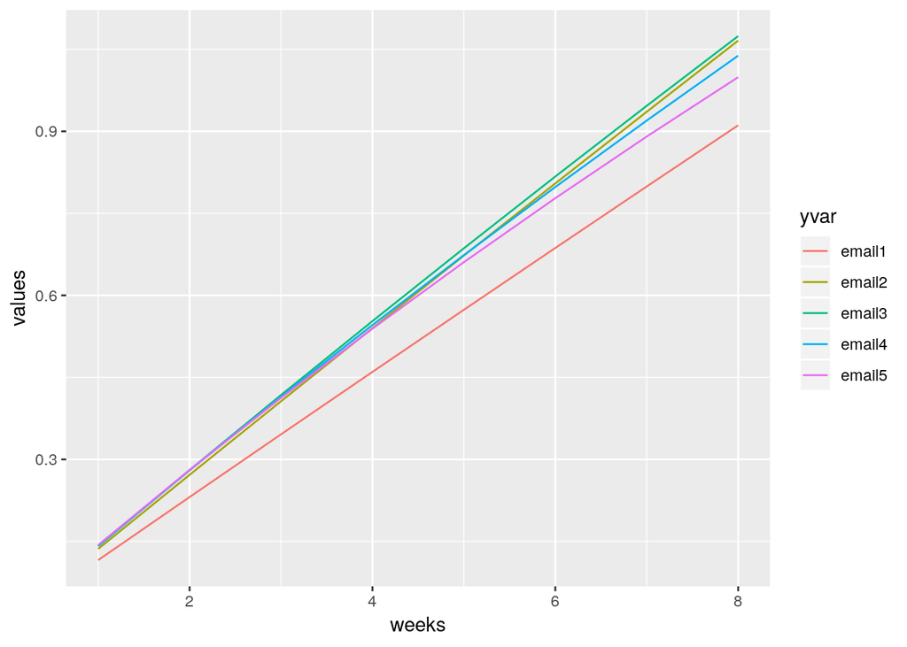

```r
## generate graph 1
graph1 <- radiant.data::visualize(
  head(tibble1,8),
   xvar = "weeks",
   yvar = c("email1", "email2","email3","email4","email5"),
    comby = TRUE,
   type = "line",
   custom = FALSE)
```

```r
graph1
```

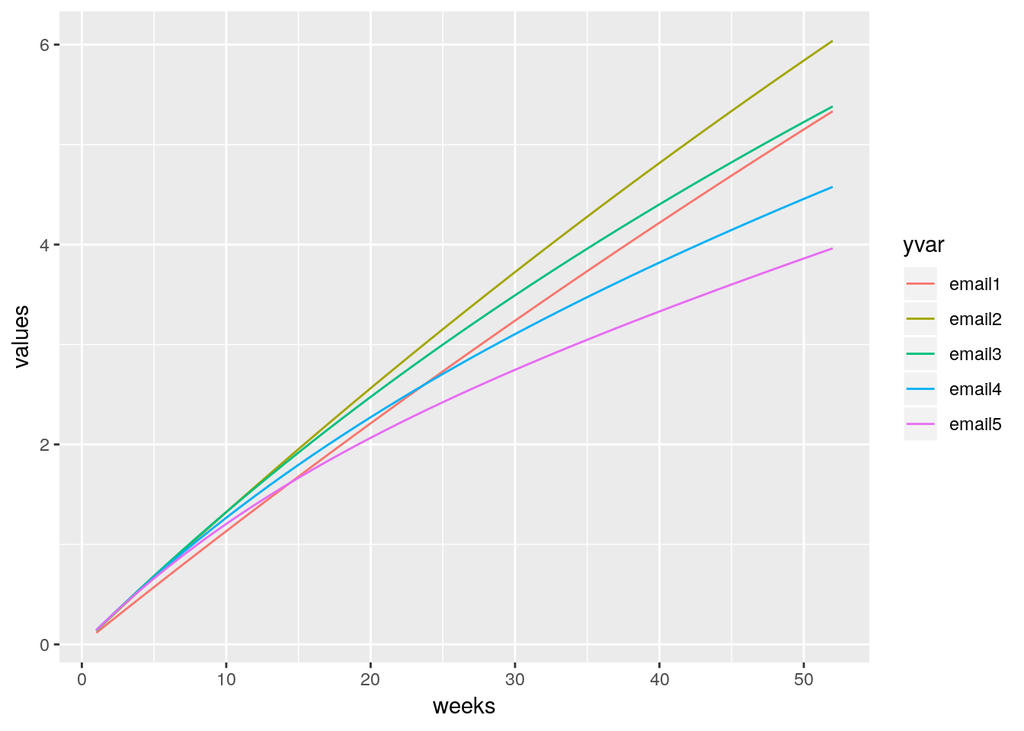

```r
## generate graph 2
graph2 <- radiant.data::visualize(
  head(tibble1,52),
   xvar = "weeks",
   yvar = c("email1", "email2","email3","email4","email5"),
    comby = TRUE,
   type = "line",
   custom = FALSE)
```

```r
graph2
```

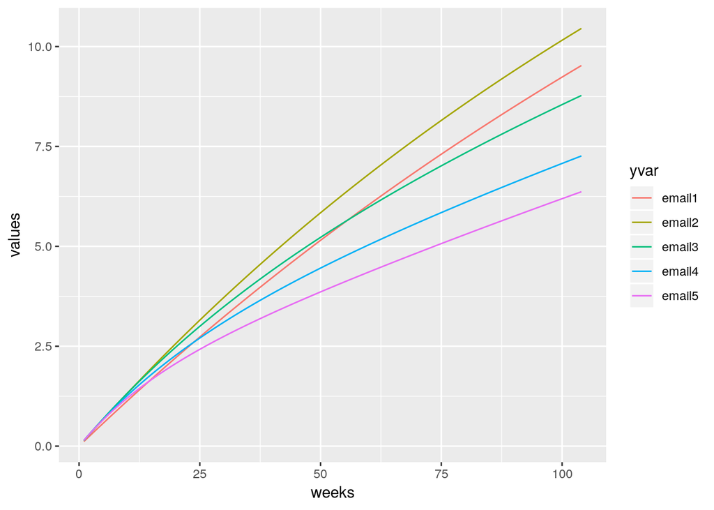

```r
## generate graph 3
graph3 <- radiant.data::visualize(
  tibble1,
   xvar = "weeks",
   yvar = c("email1", "email2","email3","email4","email5"),
    comby = TRUE,
   type = "line",
   custom = FALSE)
```

```r
graph3
```

Quesiton 5 Limitation 1.I suppose that the churn rate,revenue should not be a stable number.It is not so good to use the average number.I think churn rate will at first reduce and then become stable at a relatively low number(Customer attrition rate regardless of the number of emails sent per week,it means that those care about numbers of emails have already gone.) So to solve the problem ,I need to build a model when I have a medium period data.I am sure the churn rate will go down to a stable rate and I will use that rate to calculate. 2.When calculate revenue,I think we need to consider a growth rate.So the business will enjoy a stable growth rate(considering the inflation and economic growth).We can use history data to assume that rate.

Please generate a *reproducible* Notebook or HTML report with all your results and your answers to the questions listed in the pentathlon-II.pdf file on Dropbox.

When you have finished editing this Rmarkdown document make sure to save, commit, and push it to GitLab. We will collect all the rmarkdown files from GitLab after the due date.